# Time Series Notes

JD Long

6/26/2018

## Intro

Rob Hyndman from Monash University has been teaching and researching time series analysis for 20 years. He is the author of the R package `forcast` (https://github.com/robjhyndman/forecast). This package has long been a staple for time series analysis in R. His latest book is called *Forecasting: Principles and Practice* and is available online at https://otexts.org/fpp2/. The book has an accompanying package called `fpp2` which has example code and data from the book.

Load up the needed packages:

```r
library(fpp2)
library(ggplot2)
library(magrittr)
```

## Day One

Exercise data is here: https://robjhyndman.com/seminars/NYC2018/

The first day was spent incrementally working through the plotting and modeling methods in `forecast`. Examples were done building up each type of time series model. Then we looked at time series cross validation methods. The culmination of the day was learning the `ets` model which is an autofitted model that goes through a number of combinations of models and automagically picks the model that fits the data the best.

### ETS example:

```r
## example data
retaildata <- read.csv("https://robjhyndman.com/nyc2018/retail.csv")
mytimeseries <- ts(retaildata[,4], frequency=12, start=c(1982,4))

ets(mytimeseries)
```

```
## ETS(M,Ad,M)
##
## Call:
##  ets(y = mytimeseries)
##
##   Smoothing parameters:
##     alpha = 0.7718
##     beta  = 0.0025
##     gamma = 0.0561
##     phi   = 0.98
##
##   Initial states:
##     l = 64.0899
##     b = 0.2813
##     s=0.9869 0.9362 1.0043 1.1705 1.0216 1.0293
##            0.9848 0.9998 0.993 0.9436 0.9694 0.9606
##
##   sigma:  0.0464
##
##      AIC     AICc      BIC
## 4404.041 4405.697 4477.272
```

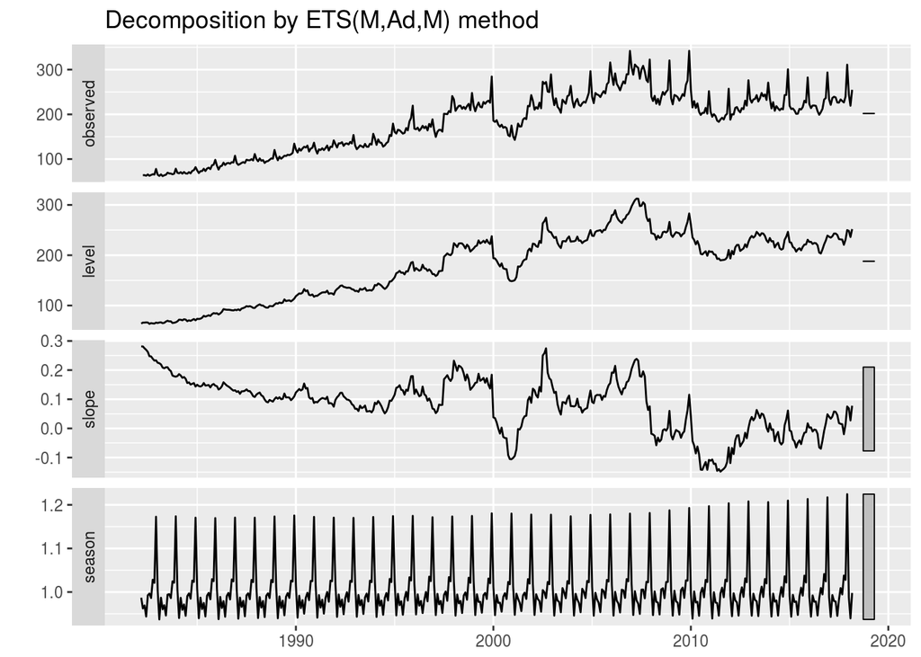

```r
ets(mytimeseries) %>% autoplot()
```

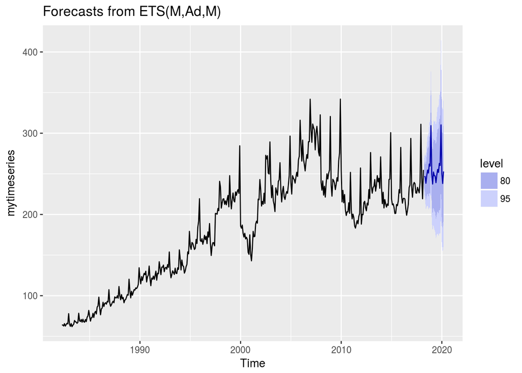

```r
ets(mytimeseries) %>% forecast() %>% autoplot()
```

```r
USAccDeaths %>%
  ets %>%
  forecast ->
forecasted_stuff

head(forecasted_stuff)
```

```
## $model
## ETS(A,N,A)
##
## Call:
##  ets(y = .)
##
##   Smoothing parameters:
##     alpha = 0.5946
##     gamma = 0.002
##
##   Initial states:
##     l = 9248.3628
##     s=-51.3449 -255.3528 218.2901 -121.771 970.7387 1683.237
##            756.092 306.4212 -489.5627 -739.9004 -1537.792 -739.0552
##
##   sigma:  292.6907
##
##      AIC     AICc      BIC
## 1140.145 1148.716 1174.295
##
## $mean
##            Jan       Feb       Mar       Apr       May       Jun       Jul
## 1979  8397.497  7599.221  8396.595  8646.510  9443.412  9893.065 10819.124
## 1980  8397.497  7599.221  8396.595  8646.510  9443.412  9893.065 10819.124
##            Aug       Sep       Oct       Nov       Dec
## 1979 10107.105  9015.233  9354.407  8880.418  9085.492
## 1980 10107.105  9015.233  9354.407  8880.418  9085.492
##
## $level
## [1] 80 95
##
## $x
##        Jan   Feb   Mar   Apr   May   Jun   Jul   Aug   Sep   Oct   Nov
## 1973  9007  8106  8928  9137 10017 10826 11317 10744  9713  9938  9161
## 1974  7750  6981  8038  8422  8714  9512 10120  9823  8743  9129  8710
## 1975  8162  7306  8124  7870  9387  9556 10093  9620  8285  8466  8160
## 1976  7717  7461  7767  7925  8623  8945 10078  9179  8037  8488  7874
## 1977  7792  6957  7726  8106  8890  9299 10625  9302  8314  8850  8265
## 1978  7836  6892  7791  8192  9115  9434 10484  9827  9110  9070  8633
##        Dec
```

[output cut: 45 more lines]

```
## Oct 1979  8587.349 8181.293
## Nov 1979  8081.593 7658.721
## Dec 1979  8255.912 7816.759
## Jan 1980  7538.459 7083.713
## Feb 1980  6711.703 6241.880
## Mar 1980  7481.483 6997.052
## Apr 1980  7704.612 7206.001
## May 1980  8475.469 7963.070
## Jun 1980  8899.759 8373.935
## Jul 1980  9801.087 9262.171
## Aug 1980  9064.924 8513.227
## Sep 1980  7949.455 7385.266
## Oct 1980  8265.543 7689.133
## Nov 1980  7768.947 7180.570
## Dec 1980  7951.715 7351.530
```

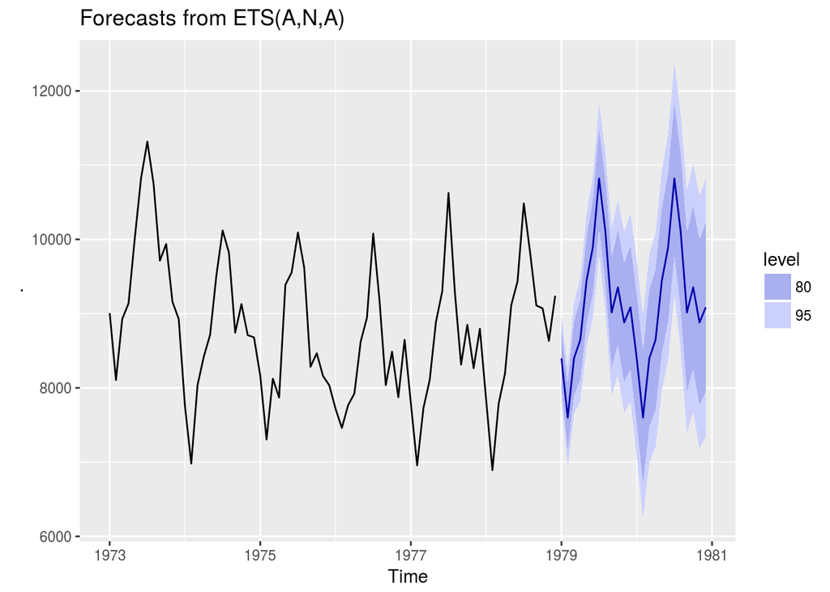

```r
forecasted_stuff %>%
  autoplot
```

## Day 2

Transformations using Box Cox

### Multiple Seasonal Decomposition

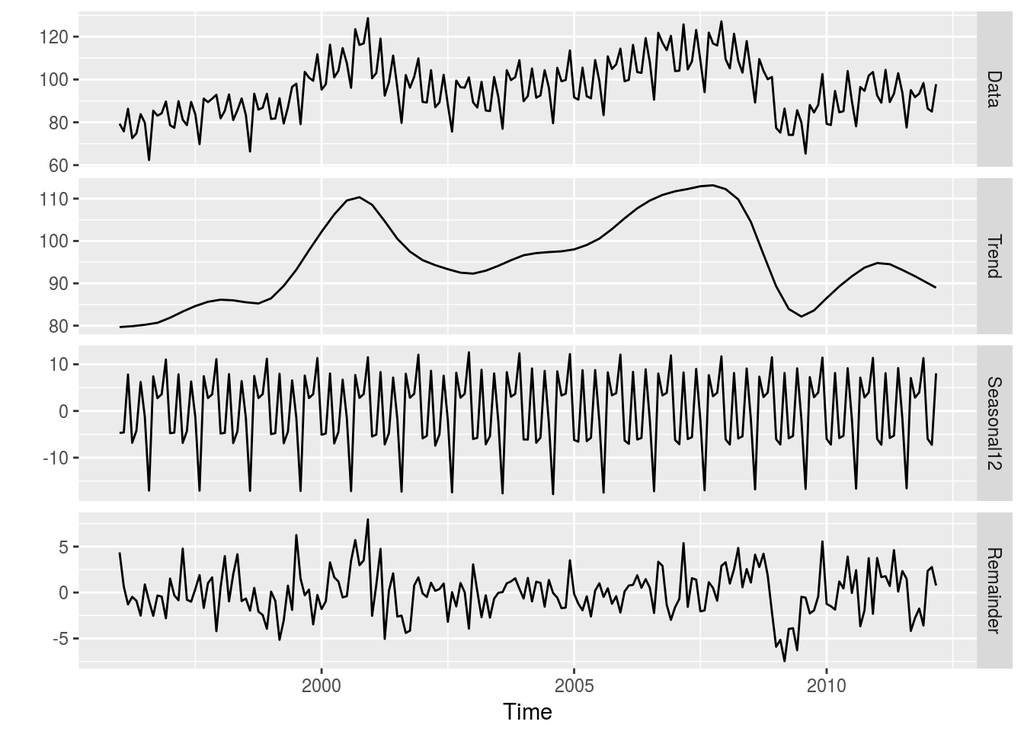

```r
elecequip %>%
  mstl %>%
  autoplot
```

worked with the components:

- `t.window` controls wiggliness of trend component.
- `s.window` controls variation on seasonal component.
- `seasonal()` extracts seasonal component
- `trendcycle()` extracts trend component
- `remainder()` extracts remainder component
- `seasadj()` computes seasonally adjusted data

Built up incrementally and then looked at residuals:

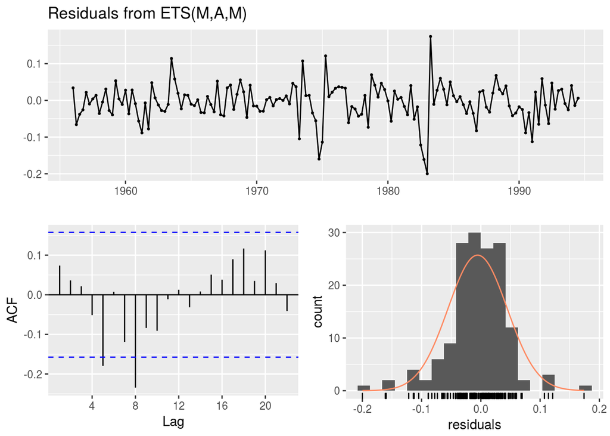

```
##
##  Ljung-Box test
##
## data:  Residuals from ETS(M,A,M)
## Q* = 20.813, df = 3, p-value = 0.0001151
##
## Model df: 8.   Total lags used: 11
```

```r
bricksq %>%
  ets( ) ->
  fitted_stuff

checkresiduals(fitted_stuff)
```

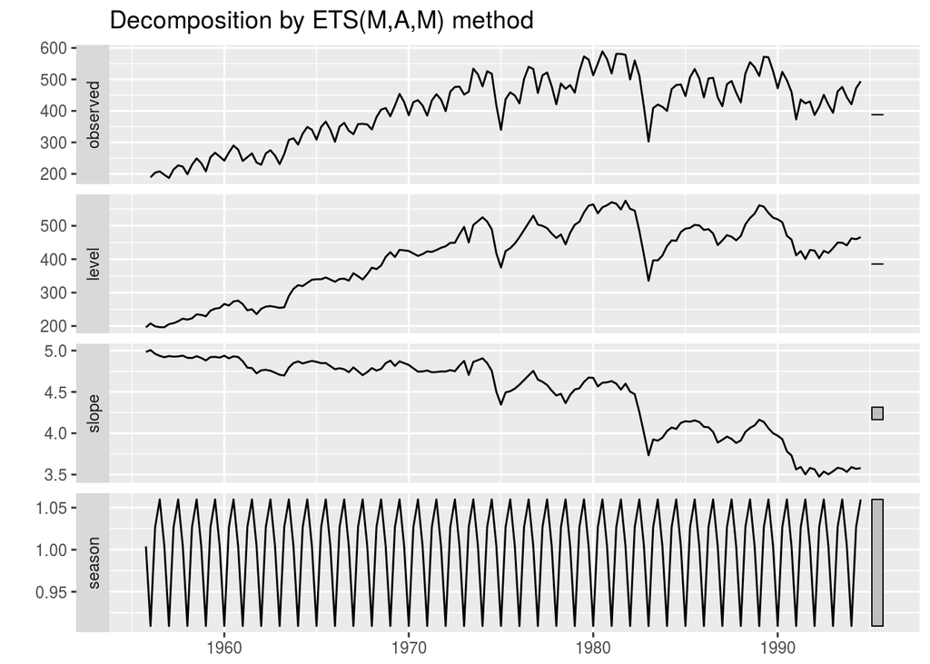

```r
autoplot(fitted_stuff)
```

```r
accuracy(fitted_stuff)
```

```
##                     ME     RMSE      MAE        MPE     MAPE      MASE
## Training set -2.813563 21.57283 15.23174 -0.8081025 3.755501 0.4278259
##                   ACF1
## Training set 0.1478444
```

## ARIMA

https://otexts.org/fpp2/arima.html

ETS models do not depend on being stationary? ARIMA models do require stationarity.

ACF for stationary data drops to zero quickly (faster than linear).

This is NOT stationary:

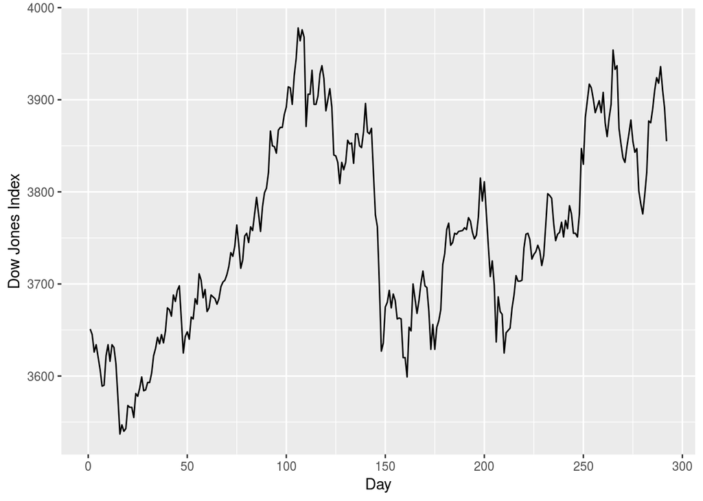

```r
autoplot(dj) + ylab("Dow Jones Index") + xlab("Day")
```

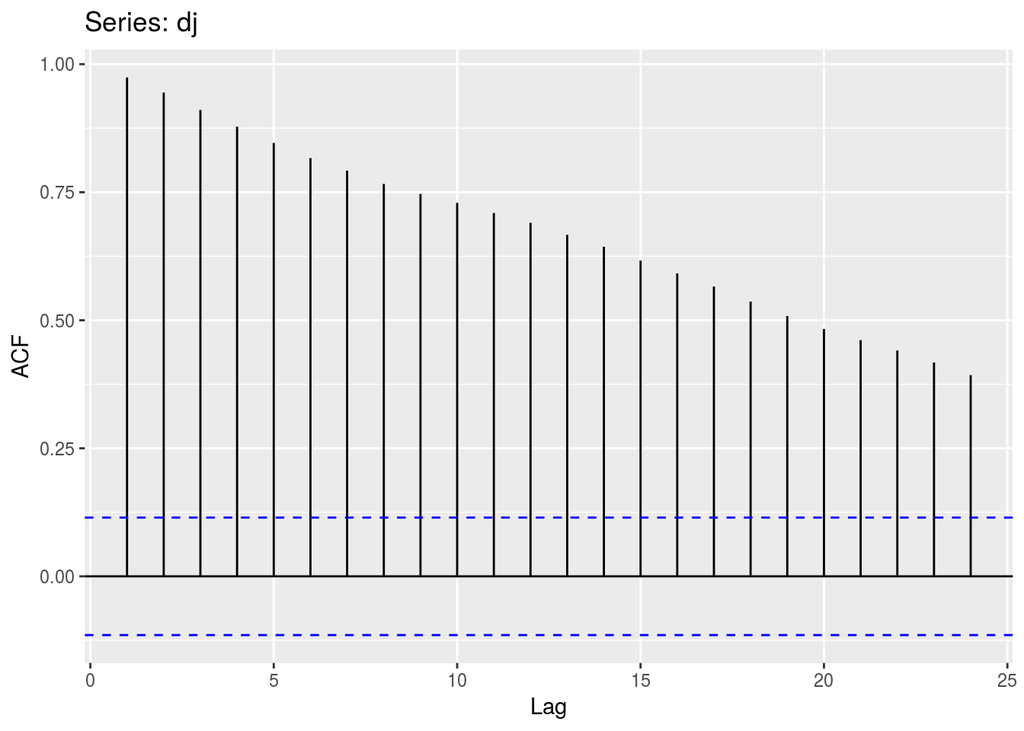

```r
ggAcf(dj)
```

But a simple `diff` will make it stationary:

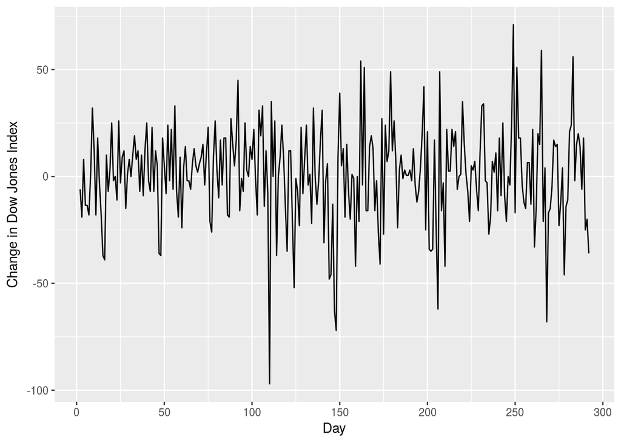

```r
autoplot(diff(dj)) +
ylab("Change in Dow Jones Index") + xlab("Day")
```

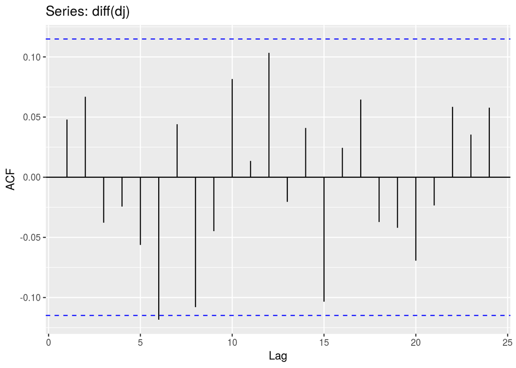

```r
ggAcf(diff(dj))
```

for non stationary data r1 is often large and positive

Discussion of KPSS & Augmented Dickey Fuller tests. KPSS and Dickey Fuller have reverse null hypothesis, because they like messing with us, I presume.

```r
library(urca)
summary(ur.kpss(goog))
```

```
##
## #######################
## # KPSS Unit Root Test #
## #######################
##
## Test is of type: mu with 7 lags.
##
## Value of test-statistic is: 10.7223
##
## Critical value for a significance level of:
##                 10pct  5pct 2.5pct  1pct
## critical values 0.347 0.463  0.574 0.739
```

```r
## forecast package has this helper function to make all this less painful
## only works for non seasonal data.
ndiffs(goog)
```

```
## [1] 1
```

`auto.arima` takes care of the lags, but it does not do the Box Cox transform. So in practice just transform it, then `auto.arima` or `ets` then go have a sammich.

```r
a10 %>%
  BoxCox.lambda() ->
  lambda

a10 %>%
  BoxCox(lambda) %>%
  auto.arima() ->
  fit

print(fit)
```

```
## Series: .
## ARIMA(3,0,3)(0,1,1)[12] with drift
##
## Coefficients:
##           ar1      ar2     ar3     ma1     ma2      ma3     sma1   drift
##       -0.0607  -0.0007  0.7459  0.0751  0.2973  -0.4682  -0.8276  0.0126
## s.e.   0.1207   0.1087  0.0966  0.1440  0.1246   0.1357   0.0663  0.0003
##
## sigma^2 estimated as 0.006168:  log likelihood=213.52
## AIC=-409.03   AICc=-408.04   BIC=-379.72
```

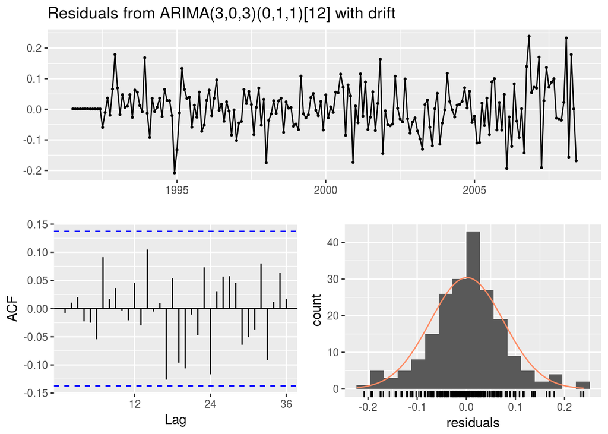

```
##
##  Ljung-Box test
##
## data:  Residuals from ARIMA(3,0,3)(0,1,1)[12] with drift
## Q* = 20.172, df = 16, p-value = 0.2126
##
## Model df: 8.   Total lags used: 24
```

```r
checkresiduals(fit, plot=TRUE)
```

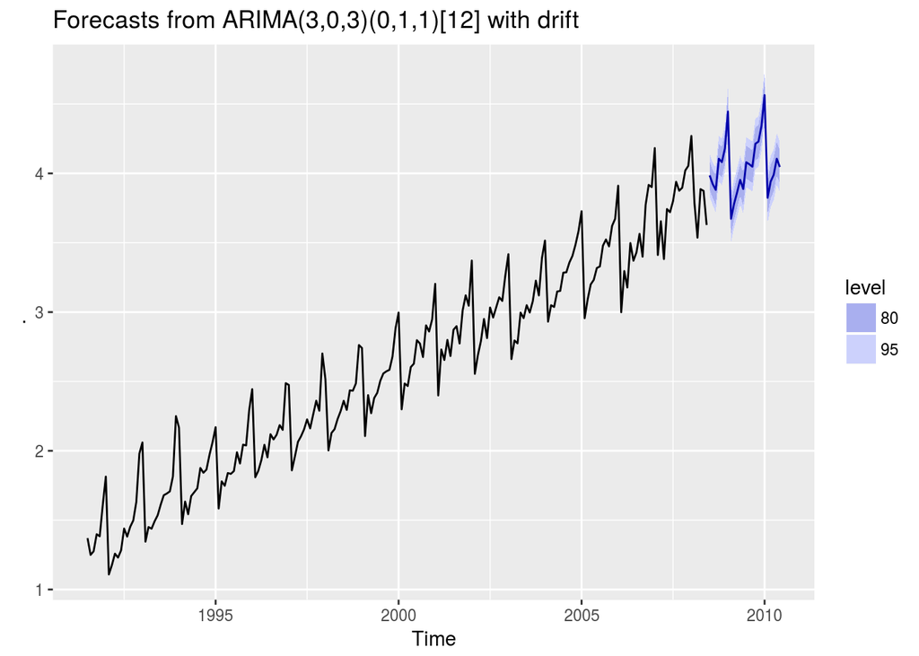

```r
fit %>% forecast() %>% autoplot()
```

## Day 3:

### Regression with ARIMA errors

Can’t bring regression into ETS, must use ARIMA.

Rob encourages avoiding ARMIAx models as the coefficients are not inheritable. Stick to modeling the error as an ARIMA.

Could do an `lm`, grab errors, then `auto.arima` on the errors. But that gives other struggles. So we do them at once:

Use MLE method by adding regression parameters to `auto.arima` Have to make categorical variables into dummies.

TBATS is a whole bag of tricks. Point forecasts are pretty good but conf bands can be nuts. Does not support covariates.

## Hierarchy Modeling:

forecast it all at all levels of aggregation reconcile results use `hts` package

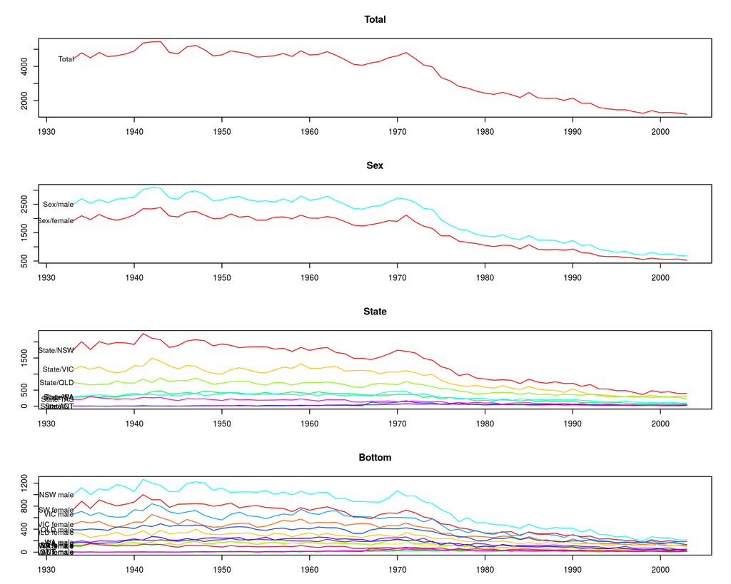

```r
library(hts)
plot(infantgts)
```

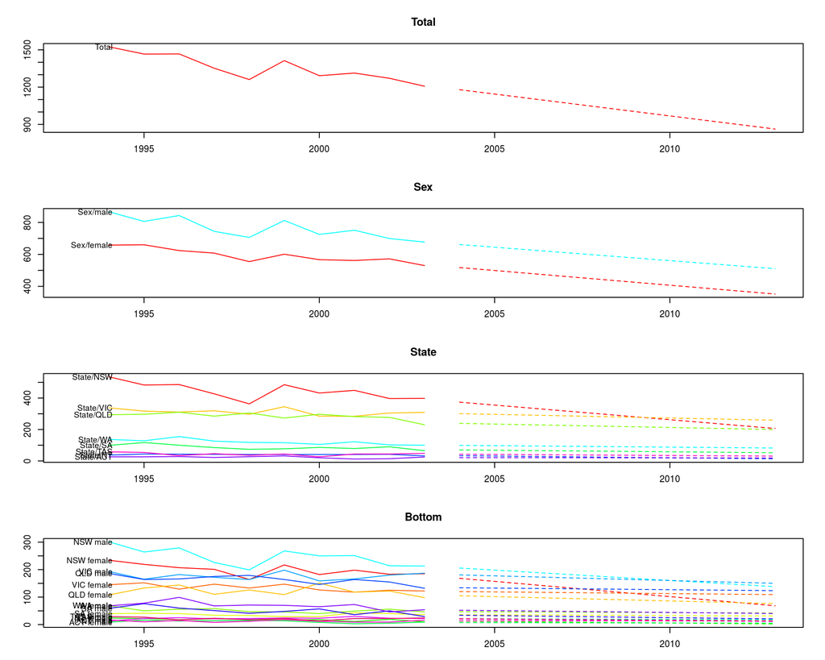

```r
# smatrix(infantgts)

# Forecast 10-steps-ahead and reconcile the forecasts
infantforecast <- forecast(infantgts, h=10)

# Plot the forecasts including only the last ten historical years
plot(infantforecast, include=10)
```

```r
# set up training and testing sets
training <- window(infantgts, end=1993)
test <- window(infantgts, start=1994)

# Compute forecasts on training data
forecast <- forecast(training, h=10)

# calculate ME, RMSE, MAE, MAPE, MPE and MASE
accuracy.gts(forecast, test)
```

```
##            Total  Sex/female    Sex/male  State/NSW   State/VIC  State/QLD
## ME   -244.904568 -78.6397682 -166.264800 -89.528833 -49.8959978 -55.411028
## RMSE  261.233834  84.9711907  177.399528  99.700183  54.2557973  60.178392
## MAE   244.904568  78.6397682  166.264800  89.528833  49.8959978  55.411028
## MAPE   18.640544  13.6834991   22.580911  21.459033  16.5137979  20.273855
## MPE   -18.640544 -13.6834991  -22.580911 -21.459033 -16.5137979 -20.273855
## MASE    1.270252   0.8425689    1.524433   1.004437   0.6793192   1.195491
##         State/SA   State/WA   State/NT  State/ACT  State/TAS   NSW female
## ME   -26.9464899 -31.790162  3.2990654  -6.010358 11.3792355 -0.004670893
## RMSE  31.1321209  36.296110  4.6344802   8.864807 15.9535292 16.161680593
## MAE   27.9384607  32.559425  4.3394392   6.534153 12.8905436 12.710039410
## MAPE  35.4269496  29.098092 10.6016741  40.096012 28.3287556  6.753982800
## MPE  -34.5791113 -28.601793  7.6772208 -38.459152 23.7483024 -0.463862406
## MASE   0.9100476   1.125974  0.3513716   1.010436  0.5678654  0.291961089
##       VIC female QLD female  SA female   WA female   NT female ACT female
## ME   -22.8309813 -34.531670 -13.444212 -10.2315375  -4.6157042  2.5342319
## RMSE  27.3256022  38.422709  14.497360  13.6482464   6.7506445  4.9449122
## MAE   22.8309813  34.531670  13.444212  12.2430985   5.2923222  4.1930541
## MAPE  18.0628069  30.572757  39.524037  25.5871175  39.3252648 47.3191619
## MPE  -18.0628069 -30.572757 -39.524037 -22.6718117 -36.4650656  0.6756466
## MASE   0.6333143   1.183267   0.763153   0.7002726   0.7436518  0.9983462
##      TAS female   NSW male    VIC male    QLD male     SA male    WA male
## ME    4.4847759 -89.524162 -27.0650165 -20.8793579 -13.5022779 -21.558625
## RMSE  6.8820615  97.024879  29.8933466  25.6346578  18.5116768  25.292667
## MAE   5.6805670  89.524162  27.0650165  21.2244291  15.8355764  23.182046
## MAPE 25.4784265  38.811661  15.9157744  14.0061014  38.7527143  37.788985
## MPE  17.7593066 -38.811661 -15.9157744 -13.8205793 -35.6825847 -36.149166
## MASE  0.5004905   1.606295   0.6193368   0.8806817   0.8283649   1.419309
##        NT male   ACT male   TAS male
## ME    7.914770  -8.544590  6.8944597
## RMSE 10.147835   9.319844  9.1388616
## MAE   9.256921   8.544590  7.4388200
## MAPE 40.840846  81.597132 32.9394177
## MPE  30.516604 -81.597132 29.7372982
## MASE  1.341583   1.697601  0.6554026
```

## Fourier Transform example

straight out of the text book. Example of searching for the best K in the Fourier:

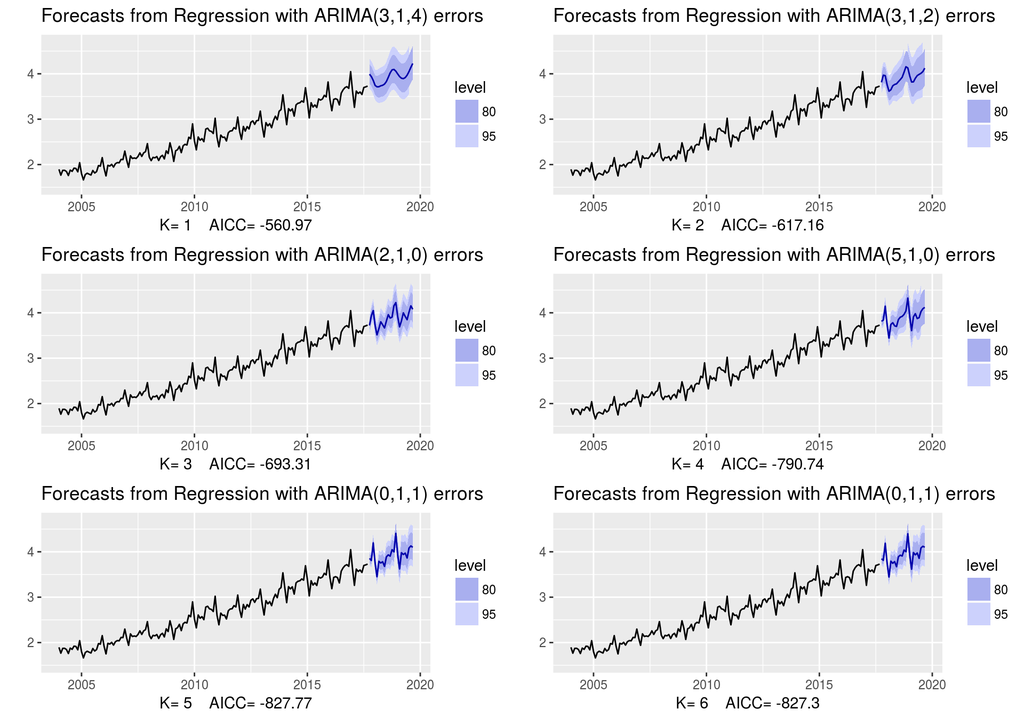

```r
cafe04 <- window(auscafe, start=2004)
plots <- list()
for (i in seq(6)) {
  fit <- auto.arima(cafe04, xreg = fourier(cafe04, K = i),
    seasonal = FALSE, lambda = 0)
  plots[[i]] <- autoplot(forecast(fit,
      xreg=fourier(cafe04, K=i, h=24))) +
    xlab(paste("K=",i,"   AICC=",round(fit[["aicc"]],2))) +
    ylab("") + ylim(1.5,4.7)
}
gridExtra::grid.arrange(
  plots[[1]],plots[[2]],plots[[3]],
  plots[[4]],plots[[5]],plots[[6]], nrow=3)
```